# Regression HW 3

> 고급회귀분석 과제, CH07
- toc:true
- branch: master
- badges: true
- comments: false
- author: 최서연
- categories: [Advanced Regression Analysis]

고급회귀분석 세번째 과제입니다.

제출 기한 : 11월 21일

제출 방법

- 직접 제출(607호) 도 가능하지만,
- 문서 작성 후 pdf로 변환(★★★)하여 lms에 제출을 추천

  (pdf 아닌 문서는 미제출로 간주)

주의사항

- pdf로 꼭 변환하여 제출
- 풀이가 꼭 있어야 함 (답만 적혀 있는 경우 '0'점 처리)
- 부정행위 시 'F'학점
- 계산은 R로 해도 되지만 계산 풀이 과정이 꼭 있어야 함!!

예) R에서 lm으로 beta의 추정량을 구하면 안 됨. 수업 시간에 배운 식으로 풀이를 적어야 함.

- 행렬식 계산은 R로 해도 됩니다.

** R을 이용해서 푸는 문제는, R 코드도 같이 업로드.

#### 1. 어떤 큰 공장에서 동일한 기계들의 정비기록에 관한 표본자료를 취하였다. 이는 기계의 사용연도(age of machines)와 정비비용(maintenance cost) 간에 어떤 관계가 있는가를 밝혀내기 위한 것이다. 그 자료는 다음과 같다 (표본의 크기 $n = 14$).

| 사용연도$X$(단위:년) | 정비비용$Y$(단위:1,000원) |
| --- | --- |
| 3 | 39 |
| 1 | 24 |
| 5 | 115 |
| 8 | 105 |
| 1 | 50 |
| 4 | 86 |
| 2 | 67 |
| 6 | 90 |
| 9 | 140 |
| 3 | 112 |
| 5 | 70 |
| 7 | 186 |
| 2 | 43 |
| 6 | 126 |

```r
n <- 14
```

```r
p <- 2
```

```r
X <- matrix(c(1,1,1,1,1,1,1,1,1,1,1,1,1,1,3,1,5,8,1,4,2,6,9,3,5,7,2,6),nrow = 14,ncol = 2)
```

```r
y <- matrix(c(39,24,115,105,50,86,67,90,140,112,70,186,43,126),nrow = 14,ncol = 1)
```

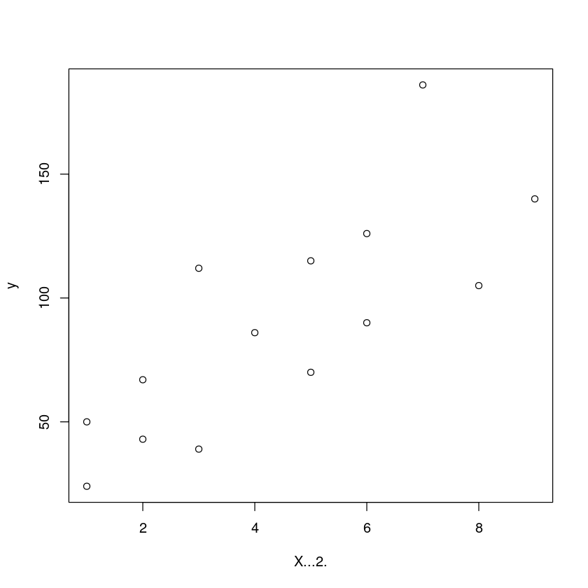

```r
plot(data.frame(X[,2],y))
```

```r
yTy <- 39^2 + 24^2 + 115^2 + 105^2 + 50^2 + 86^2 + 67^2 + 90^2 + 140^2 + 112^2 + 70^2 + 186^2 + 43^2 + 126^2
ybar <- (39 + 24 + 115 + 105 + 50 + 86 + 67 + 90 + 140 + 112 + 70 + 186 + 43 + 126)/n
cat("yTy = ",yTy)
cat("\nybar = ",ybar)
```

```
yTy =  138197
ybar =  89.5
```

$SST = \bf{y}^\top \bf{y} - n(\bar{y})^2$

```r
SST <- yTy - n * (ybar)^2
SST
```

26053.5

###### (1) $X^\top X, X^\top y, y^\top y$와 $(X^\top X)^{-1}$을 구하시오.

$X^\top X = \begin{pmatrix} 1&1&1&1&1&1&1&1&1&1&1&1&1&1\\3&1&5&8&1&4&2&6&9&3&5&7&2&6 \end{pmatrix}\begin{pmatrix} 1&3 \\ 1&1 \\ 1&5 \\ 1&8 \\ 1&1 \\ 1&4 \\ 1&2\\ 1&6 \\ 1& 9 \\ 1 &3 \\ 1 &5 \\ 1&7 \\ 1&2 \\ 1&6 \end{pmatrix}$

```r
cat(1*14,",",3+1+5+8+1+4+2+6+9+3+5+7+2+6,"\n",3+1+5+8+1+4+2+6+9+3+5+7+2+6,",",3^2+1^2+5^2+8^2+1^2+4^2+2^2+6^2+9^2+3^2+5^2+7^2+2^2+6^2)
```

```
14 , 62
 62 , 360
```

```r
t(X) %*% X
```

A matrix: 2 × 2 of type dbl

| 14 | 62 |
| --- | --- |
| 62 | 360 |

$X^\top y = \begin{pmatrix} 1&1&1&1&1&1&1&1&1&1&1&1&1&1\\3&1&5&8&1&4&2&6&9&3&5&7&2&6 \end{pmatrix} \begin{pmatrix}39\\24\\115\\105\\50\\86\\67\\90\\140\\112\\70\\186\\43\\126 \end{pmatrix}$

```r
cat("",39 + 24 + 115 + 105 + 50 + 86 + 67 + 90 + 140 + 112 + 70 + 186 + 43 + 126,"\n",3*39 + 1*24 + 5*115 + 8*105 + 1*50 + 4*86 + 2*67 + 6*90 + 9*140 + 3*112 + 5*70 + 7*186 + 2*43 + 6*126)
```

```
 1253
 6714
```

```r
t(X) %*% y
```

A matrix: 2 × 1 of type dbl

| 1253 |
| --- |
| 6714 |

$y^\top y = \begin{pmatrix} 39&24&115&105&50&86&67&90&140&112&70&186&43&126 \end{pmatrix} \begin{pmatrix}39\\24\\115\\105\\50\\86\\67\\90\\140\\112\\70\\186\\43\\126 \end{pmatrix}$

```r
39^2 + 24^2 + 115^2 + 105^2 + 50^2 + 86^2 + 67^2 + 90^2 + 140^2 + 112^2 + 70^2 + 186^2 + 43^2 + 126^2
```

138197

```r
t(y) %*% y
```

A matrix: 1 × 1 of type dbl

| 138197 |
| --- |

$(X^\top X)^{-1} = \begin{pmatrix} 14&62\\62&360 \end{pmatrix}^{-1} = \frac{1}{14\times360 - 62^2} \begin{pmatrix} 360 & -62 \\ -62 & 14 \end{pmatrix}$

```r
cat(" ",(1/(360*14 -62^2))*360,",",(1/(360*14 -62^2))*(-62),"\n",(1/(360*14 -62^2))*(-62),",",(1/(360*14 -62^2))*14)
```

```
  0.3010033 , -0.05183946
 -0.05183946 , 0.01170569
```

```r
solve(t(X) %*% X)
```

A matrix: 2 × 2 of type dbl

| 0.30100334 | -0.05183946 |
| --- | --- |
| -0.05183946 | 0.01170569 |

###### (2) $\hat{\beta} = (X^\top X)^{-1}X^\top y$를 구하고, 적합된 회귀선형을 써 보아라.

```r
betahat <- solve(t(X) %*% X) %*% t(X) %*% y
betahat
```

A matrix: 2 × 1 of type dbl

| 29.10702 |
| --- |
| 13.63712 |

$$\hat{y} = 29.10702 + 13.63712 x$$

사용연도 𝑋 (단위:년)가 1년 증가할 때 정비비용 𝑌 (단위:1,000원)는 13,637.12원 증가한다.

$SSR = \hat{\beta}^\top X^\top \bf{y} - n(\bar{y})^2$

```r
SSR <- t(betahat) %*% t(X) %*% y - n * (ybar)^2
round(SSR[,1],5)
```

15887.24916

###### (3) $\sigma^2$을 MSE 로 추정할 경우, $\hat{\beta}$의 분산-공분산행렬의 추정은 $\hat{Var}(\hat{\beta}) = (X^\top X)^{-1}$(MSE)이다. 먼저 분산분석하여 MSE 를 구하고 $\hat{Var}(\hat{\beta})$을 구하시오

```r
df_e <- n - (p + 1)
df_e
```

11

$SSE = \bf{y}^\top \bf{y} - \hat{\beta}^\top X^\top \bf{y} = SST - SSR$

```r
SSE <- t(y) %*% y - t(betahat) %*% t(X) %*% y
round(SSE[,1],5)
```

10166.25084

```r
cat("SST - SSR = SSE = ",round((SST - SSR)[,1],5))
```

```
SST - SSR = SSE =  10166.25
```

```r
MSE <- SSE/df_e
cat("MSE = ",round(MSE[,],5))
```

```
MSE =  924.2046
```

```r
solve(t(X) %*% X) * MSE[,]
```

A matrix: 2 × 2 of type dbl

| 278.18868 | -47.91027 |
| --- | --- |
| -47.91027 | 10.81845 |

$\hat{Var}(\hat{\beta}) = \begin{pmatrix} 278.18868 &-47.91027 \\ -47.91027 & 10.81845 \end{pmatrix}$

#### 2.어떤 공정에서 나오는 제품의 강도$(kg/cm^2)$가 그 공정의 온도와 압력에 어떠한 영향을 받는가를 조사하기 위하여 다음의 데이터를 얻었다.

| 공정온도$x_1$(단위:°C) | 공정압력$x_2$(단위:$psi$) | 강도$y$(단위:$kg/cm^2$) |
| --- | --- | --- |
| 195 | 57 | 81.4 |
| 179 | 61 | 122.2 |
| 205 | 60 | 101.7 |
| 204 | 62 | 175.6 |
| 201 | 61 | 150.3 |
| 184 | 54 | 64.8 |
| 210 | 58 | 92.1 |
| 209 | 61 | 113.8 |

```r
n <- 8
```

```r
X <- matrix(c(1,1,1,1,1,1,1,1,195,179,205,204,201,184,210,209,57,61,60,62,61,54,58,61),nrow=8,ncol=3)
y <- matrix(c(81.4,122.2,101.7,175.6,150.3,64.8,92.1,113.8),nrow=8,ncol=1)
```

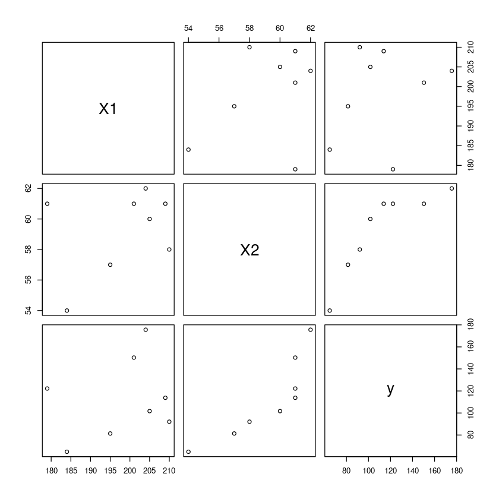

```r
pairs(data.frame(X[,c(2,3)],y))
```

$SST = \bf{y}^\top \bf{y} - n(\bar{y})^2$

```r
yTy <- (81.4^2 + 122.2^2 + 101.7^2 + 175.6^2 + 150.3^2 + 64.8^2 + 92.1^2 + 113.8^2)
ybar <- (81.4 + 122.2 + 101.7 + 175.6 + 150.3 + 64.8 + 92.1 + 113.8)/n
cat("yTy = ",yTy)
cat("\nybar = ",ybar)
```

```
yTy =  110959
ybar =  112.7375
```

```r
SST <- yTy - n * (ybar)^2
cat("SSR = ",round(SST,5))
```

```
SSR =  9281.079
```

###### (1) 선형회귀모형, $y_j = \beta_0 + \beta_1 x_{1j} + \beta_2 x_{2j} + \epsilon_j$ 가 성립된다고 가정하고 데이터로부터 회귀모형을 추정하시오.

```r
p <- 2
```

$\hat{\beta} = (X^\top X)^{-1} X^\top \bf{y}$

```r
betahat <- solve(t(X) %*% X) %*% t(X) %*% y
round(betahat,5)
```

A matrix: 3 × 1 of type dbl

| -554.31122 |
| --- |
| -0.17974 |
| 11.85999 |

$\hat{y} = -554.31122 -0.17974 x_{1j} + 11.85999 x_{2j}$

$SSR = \hat{\beta}^\top X^\top \bf{y} - n(\bar{y})^2$

```r
SSR <- t(betahat) %*% t(X) %*% y - n * (ybar)^2
cat("SSR = ",round(SSR[,],5))
```

```
SSR =  6940.195
```

###### (2) 오차분산이 $\sigma^2 = 3$이라 하면, $Var(\hat{\beta}_0), Var(\hat{\beta}_1), Var(\hat{\beta}_2)$와 $Cov(\hat{\beta}_1, \hat{\beta}_2)$는 무엇인가?

$Var(\hat{\beta}) = (X^\top X)^{-1} \sigma^2$

```r
var_betahat <- solve(t(X) %*% X) * 3
var_betahat
```

A matrix: 3 × 3 of type dbl

| 248.6249683 | -0.403796751 | -2.837920471 |
| --- | --- | --- |
| -0.4037968 | 0.003726798 | -0.005662562 |
| -2.8379205 | -0.005662562 | 0.066856223 |

$Var(\hat{\beta}_0) = 248.6249683$

$Var(\hat{\beta}_1) = 0.003726798$

$Var(\hat{\beta}_2) = 0.066856223$

$Cov(\hat{\beta}_1, \hat{\beta}_2) = -0.005662562$

###### (3) $x_1 = 200$°C이고 $x_2 = 59\text{psi}$에서 평균 제품의 강도의 추정값 $\hat{y}$는 얼마인가? 이의 분산을 $\sigma^2 = 3$이라 가정하고 구하시오.

```r
x_indi <- matrix(c(1,200,59),nrow=1,ncol=3)
x_indi
```

A matrix: 1 × 3 of type dbl

| 1 | 200 | 59 |
| --- | --- | --- |

```r
cat("추정값 yhat = ",round((x_indi %*% betahat)[,1],5))
```

```
추정값 yhat =  109.4804
```

$Var(\hat{y}) = x (X^\top X)^{-1} x^\top \sigma^2$

```r
var_yhat <- x_indi %*% solve(t(X) %*% X) %*% t(x_indi) *3
round(var_yhat[,1],5)
```

0.39362

$Var(\hat{y}) = 0.39362$

###### (4) 추정된 회귀계수 $\hat{\beta}_1, \hat{\beta}_2$의 의미는 무엇인가?

$\hat{y} = -554.31122 -0.17974 x_{1j} + 11.85999 x_{2j}$

- 공정압력$x_2$(단위:𝑝𝑠𝑖)이 변하지 않는다고 가정한 상태에서 공정온도$x_1$(단위:°C)가 1°C올라갈때, 강도$y$(단위:$𝑘𝑔/𝑐𝑚^2$)가 $0.17974 𝑘𝑔/𝑐𝑚^2$만큼 감소한다.
- 공정온도$x_1$(단위:°C)가 변하지 않는다고 가정한 상태에서 공정압력$x_2$(단위:𝑝𝑠𝑖)이 1𝑝𝑠𝑖 올라갈때, 강도$y$(단위:$𝑘𝑔/𝑐𝑚^2$)가 $11.85999 𝑘𝑔/𝑐𝑚^2$만큼 증가한다.

###### (5) 분산분석표를 작성하고 $\alpha = 0.05$로 $F$-검정을 행하시오.

```r
cat("SST = ",round(SST,5))
cat("\nSSR = ",round(SSR[,1],5))
SSE = SST - SSR
cat("\nSSE = ",round(SSE[,1],5))
MSR = SSR / p
MSE = SSE / (n-(p+1))
cat("\nMSR = ",round(MSR[,1],5))
cat("\nMSE = ",round(MSE[,1],5))
cat("\nF_0 = ",round(MSR[,1]/MSE[,1],5))
cat("\n유의확률 = ",round(pf(0.05,2,5) * 100,5))
```

```
SST =  9281.079
SSR =  6940.195
SSE =  2340.884
MSR =  3470.097
MSE =  468.1768
F_0 =  7.41194
유의확률 =  4.83011
```

가설 : $H_0 : \beta_1 = \beta_2 = 0 \text{ vs. } H_1 : \text{ not } H_0$

| 요인 | 제곱합 | 자유도(df) | 평균제곱(MS) | $F_0$ | 유의확률 |
| --- | --- | --- | --- | --- | --- |
| 회귀 | 6940.195 | 2 | 3470.097 | 7.41194 | 4.83011 |
| 잔차 | 2340.884 | 5 | 468.1768 |  |  |
| 계 | 9281.079 | 7 |  |  |  |

- $F_0 = 7.41194 > F_\alpha(p,n-p-1) = F_{0.05}(2,5) = 4.83011$이므로 귀무가설을 기각한다.
- 따라서 $\beta_1$과 $\beta_2$가 모두 0과 같지 않거나 $\beta_1$이 0과 같지 않거나 $\beta_2$가 0과 같지 않다고 할 수 있다.

###### (6) 결정계수 $R^2$을 구하시오.

$R^2 = \frac{SSR}{SST} = 1-\frac{SSE}{SST}$

```r
cat("SSR/SST = ",round((SSR/SST)[,1]*100,5))
cat("\n1- SSE/SST = ",round((1-SSE/SST)[,1]*100,5))
```

```
SSR/SST =  74.77789
1- SSE/SST =  74.77789
```

```r
cat("결정계수 R^2 = ",round((SSR/SST)[,1]*100,2))
```

```
결정계수 R^2 =  74.78
```

###### (7) 수정된 결정계수 $R^2_{adj}$ 을 구하시오.

$R^2_{adj} = 1-\frac{SSE/(n-p-1)}{SST/(n-1)}$

```r
cat("SSE/(n-p-1) = ", (SSE/(n-p-1))[,1])
cat("\nSST/(n-1) = ", SST/(n-1))
cat("\nSSE/(n-p-1)/SST/(n-1) = ", (SSE/(n-p-1) / SST/(n-1))[,1])
cat("\nR^2_adj = ", (1-((SSE/(n-p-1))/(SST/(n-1))))[,1])
```

```
SSE/(n-p-1) =  468.1768
SST/(n-1) =  1325.868
SSE/(n-p-1)/SST/(n-1) =  0.007206317
R^2_adj =  0.6468905
```

```r
cat("수정된 결정계수 R^2_adj = ",round((1 - ( SSE/(n-p-1) ) / ( SST/(n-1) ))[,1] * 100,2))
```

```
수정된 결정계수 R^2_adj =  64.69
```

###### (8) $\sigma^2$의 추정값 MSE 를 구하시오.

$\hat{\sigma}^2 = MSE = \frac{SSE}{n-p-1}$

```r
cat("sigma^2의 추정값 MSE = ",round(MSE[,1],5))
```

```
sigma^2의 추정값 MSE =  468.1768
```

###### (9) MSR의 기대값을 $\sigma^2$과 $\beta_0, \beta_1, \beta_2$의 함수로 표시하여라.

$E(SSR) = E(y^\top [X(X^\top X)^{-1}X^\top - \frac{J_n}{n}] y)$

<정리 5.1> 만약 $\bf{y} \sim N(\mu,V)$이면

- $E(\bf{y}^\top A \bf{y}) = tr(AV) + \mu^\top A \mu$
- $Cov(\bf{y},\bf{y}^\top A \bf{y}) = 2V A \mu$

$X(X^\top X)^{-1}X^\top - \frac{J_n}{n} = A$

$\mu = E(\bf{y}) = X \beta$

$Var(\bf{y}) = I_n \sigma^2$

$E(SSR) = E(\bf{y}^\top A \bf{y}) = tr(A _n \sigma^2) + (X \beta)^\top A X \beta$

$ = \sigma^2 tr(A_n) + \beta^\top X^\top A X \beta$

$\star tr(A_n) = tr(X(X^\top X)^{-1}X^\top - \frac{J_n}{n}) = tr(X(X^\top X)^{-1}X^\top) - tr(\frac{J_n}{n}) = tr(XX^{-1}(X^\top)^{-1}X^\top) - tr(\frac{J_n}{n}) = (p+1) - 1 = p$

$ = p \sigma^2 + \beta^\top X^\top (X(X^\top X)^{-1}X^\top - \frac{J_n}{n}) X \beta = p \sigma^2 + \beta^\top X^\top (I_n - \frac{J_n}{n}) X \beta$

$\therefore E(MSR) = E(\frac{SSR}{p}) = \sigma^2 + \frac{1}{p}\beta^\top X^\top (I_n - \frac{J_n}{n}) X \beta$

$ = \sigma^2 + \frac{1}{p}(\beta^\top X^\top X\beta - \beta^\top X^\top\frac{J_n}{n}X \beta)$

$ = \sigma^2 + \frac{1}{p}\beta^\top(\begin{bmatrix} n & \sum x_{1j} & \sum x_{2j} \\ \sum x_{1j} & \sum x^2_{1j} & \sum x_{1j} \\ \sum x_{2j} & \sum x_{1j} & \sum x^2_{2j} \end{bmatrix} - \begin{bmatrix} n & \sum x_{1j} & \sum x_{2j} \\ \sum x_{1j} & \frac{(\sum x_1j)^2}{n} & \sum x_{1j} \\ \sum x_{2j} & \sum x_{1j} & \frac{(\sum x_{2j})^2}{n} \end{bmatrix})\beta$

$ = \sigma^2 + \frac{1}{p}\beta^\top(\begin{bmatrix} 0 & 0 & 0 \\ 0 & \sum(x_{1j} - \bar{x_1})^2 & 0 \\ 0 & 0 & \sum(x_{2j} - \bar{x_2})^2 \end{bmatrix})\beta$

$ = \sigma^2 + \frac{1}{p}\beta^2 (\sum(x_{1j} - \bar{x_1})^2 + \sum(x_{2j} - \bar{x_2})^2)$

$ = \sigma^2 + \frac{1}{p}(\beta_0^2 + \beta_1^2 + \beta_2^2)(S_{1xx} + S_{2xx})$

#### 3. 어떤 공장에서 물의 소비량을 조사하기 위하여 매달의 물소비량($y$), 평균온도($x_1$), 작업일수($x_2$)와 작업량($x_3$)에 관한 데이터를 얻었다.

| 물소비량$y$(단위:1,000톤) | 평균온도$x_1$(단위:°C) | 작업일수$x_2$(단위:일) | 작업량$x_3$(단위:1,000톤) |
| --- | --- | --- | --- |
| 2.8 | 10 | 27 | 64 |
| 3.9 | 24 | 26 | 72 |
| 3.9 | 25 | 28 | 80 |
| 4.4 | 28 | 26 | 88 |
| 3.1 | 15 | 30 | 81 |
| 3.1 | 18 | 24 | 45 |
| 3.5 | 22 | 27 | 46 |
| 3.6 | 22 | 25 | 69 |
| 3.0 | 12 | 27 | 54 |
| 3.3 | 15 | 25 | 39 |

```r
n <- 10
```

```r
y <- matrix(c(2.8, 3.9,3.9,4.4,3.1,3.1,3.5,3.6,3.0,3.3),nrow=10,ncol=1)
X <- matrix(c(1,1,1,1,1,1,1,1,1,1,10,24,25,28,15,18,22,22,12,15,27,26,28,26,30,24,27,25,27,25,64,72,80,88,81,45,46,69,54,39),nrow=10,ncol=4)
```

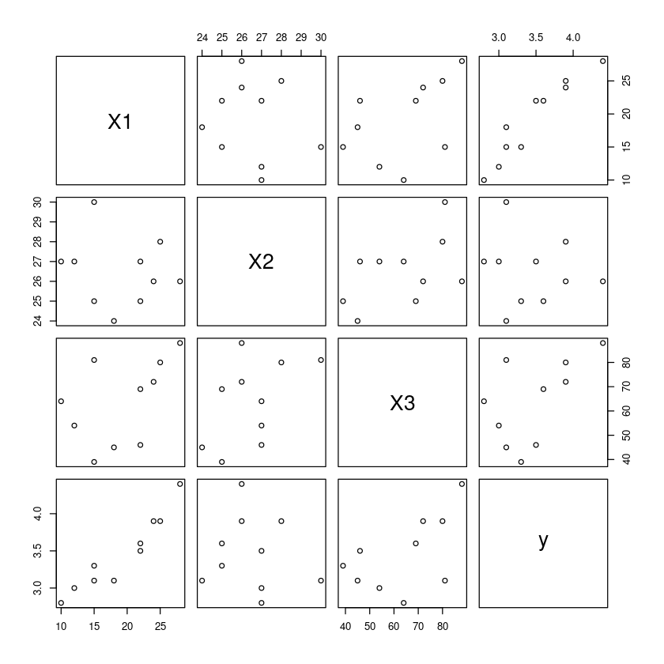

```r
pairs(data.frame(X[,c(2,3,4)],y))
```

```r
yTy <- 2.8^2 + 3.9^2 + 3.9^2 + 4.4^2 + 3.1^2 + 3.1^2 + 3.5^2 + 3.6^2 + 3.0^2 + 3.3^2
cat("yTy = ",yTy)
y_mean <- (2.8+3.9+3.9+4.4+3.1+3.1+3.5+3.6+3.0+3.3)/n
cat("\ny_mean",y_mean)
```

```
yTy =  121.94
y_mean 3.46
```

$SST = \bf{y}^\top \bf{y} - n(\bar{y})^2$

```r
SST <- yTy - n * y_mean^2
round(SST,5)
```

2.224

###### (1) 데이터로부터 회귀모형, $\hat{y} = \hat{\beta}_0 + \hat{\beta}_1 x_1 + \hat{\beta}_2 x_2 + \hat{\beta}_3 x_3$ 을 구하여라. 그리고 어째서 이 모형이 선택되었는가에 대하여 토의하시오.

```r
p <- 3
```

$\hat{\beta} = (X^\top X)^{-1} X^\top \bf{y}$

```r
betahat <- solve(t(X) %*% X) %*% t(X) %*% y
round(betahat,5)
```

A matrix: 4 × 1 of type dbl

| 2.40921 |
| --- |
| 0.06979 |
| -0.02477 |
| 0.00586 |

$\hat{y} = 2.40921 + 0.06979 x_{1} -0.02477 x_{2} + 0.00586 x_{3}$

오차제곱합

$\sum \epsilon^2 = \epsilon^\top \epsilon = (\bf{y} - X \beta)^\top (\bf{y} - X\beta) = \bf{y}^\top \bf{y} - 2 \beta^\top X^\top \bf{y} + \beta^\top X^\top X \beta$

$\frac{\partial}{\partial \beta} (\bf{y}^\top \bf{y} - 2 \beta^\top X^\top \bf{y} + \beta^\top X^\top X \beta) = 0 - \frac{\partial}{\partial \beta} \bf{y}^\top \bf{X}\beta - \frac{\partial}{\partial \beta} \beta^\top \bf{X}^\top \bf{y} + \frac{\partial}{\partial \beta} \beta^\top \bf{X}^\top \bf{X}\beta = 0 - \bf{X}^\top \bf{y} - \bf{X}^\top \bf{y} + 2\bf{X}^\top \bf{X}\beta$

$\therefore \frac{\partial}{\partial \beta} \bf{y}^\top \bf{y} - 2 \beta^\top X^\top \bf{y} + \beta^\top X^\top X \beta = 0 \leftrightarrow 2\bf{X}^\top \bf{y} = 2\bf{X}^\top \bf{X}\beta$

정규방정식

$X^\top X \hat{\beta} = X^\top \bf{y}$

최소제곱합(LSE)

$\hat{\beta} = (X^\top X)^{-1} X^\top \bf{y}$

즉, 오차의 제곱합이 최소가 되는 $\hat{\beta}$가 선택되었다.

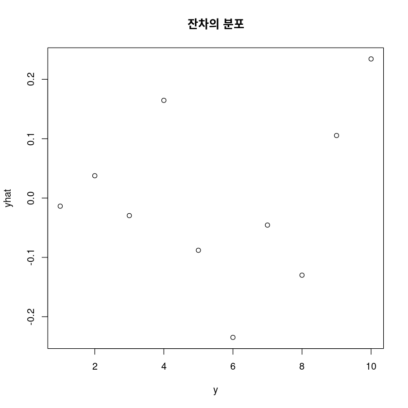

```r
plot(y - X%*%solve(t(X)%*%X)%*%t(X) %*% y,xlab="y",ylab = "yhat",main="잔차의 분포")
```

$SSR = \hat{\beta}^\top X^\top \bf{y} - n(\bar{y})^2$

```r
SSR <- t(betahat) %*% t(X) %*% y - n * (y_mean)^2
round(SSR[,1],5)
```

2.04647

###### (2) $\hat{\beta}_1, \hat{\beta}_2$와 $\hat{\beta}_3$의 의미는 무엇인가?

$\hat{y} = 2.40921 + 0.06979 x_{1} -0.02477 x_{2} + 0.00586 x_{3}$

$\hat{\beta}_1$: 작업일수$x_2$(단위:일)와 작업량$x_3$(단위:1,000톤)이 변하지 않는다고 가정한 상태에서 평균온도$x_1$(단위:°C)가 1°C 올라갈때, 물소비량$y$(단위:1,000톤)이 69.79톤만큼 증가한다.

$\hat{\beta}_2$ :평균온도$x_1$(단위:°C)와 작업량$x_3$(단위:1,000톤)이 변하지 않는다고 가정한 상태에서 작업일수$x_2$(단위:일)가 1일 증가할 때, 물소비량$y$(단위:1,000톤)이 24.77톤만큼 감소한다.

$\hat{\beta}_3$ :평균온도$x_1$(단위:°C)와 작업일수$x_2$(단위:일)가 변하지 않는다고 가정한 상태에서 작업량$x_3$(단위:1,000톤)이 1(1,000톤) 증가할 때, 물소비량$y$(단위:1,000톤)이 5.86톤만큼 증가한다.

###### (3) $Var(\hat{\beta}_3)$을 구하시오. $\sigma^2$을 MSE 로 추정하면 $\hat{Var}(\hat{\beta}_3)$은 무엇인가?

$Var(\hat{\beta}) = (X^\top X)^{-1} \sigma^2$

```r
cat("SSE = sum((y-yhat)^2) = ",round(sum(c((y - (X %*% betahat))**2)),5))
```

```
SSE = sum((y-yhat)^2) =  0.17753
```

```r
SSE = SST - SSR
cat("SST - SSR = SSE = ",round(SSE[,1],5))
MSE = SSE / (n-p-1)
cat("\nMSE = ",round(MSE[,1],5))
```

```
SST - SSR = SSE =  0.17753
MSE =  0.02959
```

```r
var_betahat <- solve(t(X) %*% X) * MSE[,1]
var_betahat
```

A matrix: 4 × 4 of type dbl

| 1.267771880 | -8.122687e-03 | -0.0493184722 | 3.092004e-03 |
| --- | --- | --- | --- |
| -0.008122687 | 1.597735e-04 | 0.0002900360 | -4.098655e-05 |
| -0.049318472 | 2.900360e-04 | 0.0020097323 | -1.485756e-04 |
| 0.003092004 | -4.098655e-05 | -0.0001485756 | 2.551868e-05 |

```r
cat("varhat_betahat_3 = ",var_betahat[4,4])
```

```
varhat_betahat_3 =  2.551868e-05
```

$\hat{Var}(\hat{\beta}_3)$는 위와 같다.

###### (4) 분산분석표를 작성하고, 결정계수 $R^2$을 구하시오.

```r
cat("SST = ",round(SST,5))
cat("\nSSR = ",round(SSR[,1],5))
cat("\nSSE = ",round(SSE[,1],5))
MSR = SSR / p
cat("\nMSR = ",round(MSR[,1],5))
cat("\nMSE = ",round(MSE[,1],5))
cat("\nF_0 = ",round(MSR[,1]/MSE[,1],5))
cat("\n유의확률 = ",round(pf(0.05,3,6) * 100,5))
```

```
SST =  2.224
SSR =  2.04647
SSE =  0.17753
MSR =  0.68216
MSE =  0.02959
F_0 =  23.05437
유의확률 =  1.61814
```

가설 : $H_0 : \beta_1 = \beta_2 = \beta_3 = 0 \text{ vs. } H_1 : \text{ not } H_0$

| 요인 | 제곱합 | 자유도(df) | 평균제곱(MS) | $F_0$ | 유의확률 |
| --- | --- | --- | --- | --- | --- |
| 회귀 | 2.04647 | 3 | 0.68216 | 23.05437 | 1.61814 |
| 잔차 | 0.17753 | 6 | 0.02959 |  |  |
| 계 | 2.224 | 9 |  |  |  |

- $F_0 = 23.05437 > F_\alpha(p,n-p-1) = F_{0.05}(3,6) = 1.61814$이므로 귀무가설을 기각한다.
- 따라서 $\beta_1, \beta_2, \beta_3$은 모두 0과 같지 않거나 0과 같지 않는 값이 적어도 하나 있다.

$R^2 = \frac{SSR}{SST} = 1-\frac{SSE}{SST}$

```r
cat("SSR/SST = ",round((SSR/SST)[,1]*100,5))
cat("\n1- SSE/SST = ",round((1-SSE/SST)[,1]*100,5))
```

```
SSR/SST =  92.01736
1- SSE/SST =  92.01736
```

```r
cat("결정계수 R^2 = ",round((SSR/SST)[,1]*100,2))
```

```
결정계수 R^2 =  92.02
```

###### (5) $x_1 = 20, x_2 = 27, x_3 = 60$에서 평균 물소비량을 추정하시오. 이 추정된 소비량의 표준편차의 추정값을 구하시오.

```r
x_indi <- matrix(c(1,20,27,60),nrow=1,ncol=4)
```

$x_{new} = \begin{pmatrix}1 & 20 & 27 & 60 \end{pmatrix}$

```r
cat("평균 물소비량 = ",round((x_indi %*% betahat)[,1],2))
```

```
평균 물소비량 =  3.49
```

$Var(\hat{y}) = x (X^\top X)^{-1} x^\top \sigma^2$

```r
var_yhat <- x_indi %*% solve(t(X) %*% X) %*% t(x_indi) * MSE
cat("var = ",round(var_yhat[,1],5))
cat("\nsigma = ",round(sqrt(var_yhat[,1]),5))
```

```
var =  0.00507
sigma =  0.07117
```

###### (6) $x_1 = 20, x_2 = 27, x_3 = 60$에서 어느 한 달의 물소비량 $y_s$ 를 예측하여라. 이 예측된 물소비량의 표준편차의 추정값을 구하시오.

```r
cat("어느 한 달의 물소비량 y_s = ",round((x_indi %*% betahat)[,1],2))
```

```
어느 한 달의 물소비량 y_s =  3.49
```

$Var(\hat{y_s}) = [1 + x^\top (X^\top X)^{-1} x] \sigma^2$

```r
var_yhat <- (1 + x_indi %*% solve(t(X) %*% X) %*% t(x_indi)) * MSE[,1]
cat("개별관측값 var(yhat_s) = ",round(var_yhat[,1],5))
cat("\nsigma = ",round(sqrt(var_yhat[,1]),5))
```

```
개별관측값 var(yhat_s) =  0.03465
sigma =  0.18616
```

###### (7) $y_j = \beta_0 + \beta_1 x_{1j} + \beta_2 x_{2j} + \epsilon_j$ 라 가정하고 회귀제곱합 SSR의 기대값을 $\sigma^2$과 $\beta_i, i = 0, 1, 2, 3$의 함수로 표시하여라.

$E(SSR) = E(y^\top [X(X^\top X)^{-1}X^\top - \frac{J_n}{n}] y)$

<정리 5.1> 만약 $\bf{y} \sim N(\mu,V)$이면

- $E(\bf{y}^\top A \bf{y}) = tr(AV) + \mu^\top A \mu$
- $Cov(\bf{y},\bf{y}^\top A \bf{y}) = 2V A \mu$

$X(X^\top X)^{-1}X^\top - \frac{J_n}{n} = A$

$\mu = E(\bf{y}) = X \beta$

$Var(\bf{y}) = I_n \sigma^2$

$E(SSR) = E(\bf{y}y^\top A \bf{y}) = tr(A _n \sigma^2) + (X \beta)^\top A X \beta$

$ = \sigma^2 tr(A) + \beta^\top X^\top A X \beta$

$\star tr(A) = tr(X(X^\top X)^{-1}X^\top - \frac{J_n}{n}) = tr(X(X^\top X)^{-1}X^\top) - tr(\frac{J_n}{n}) = tr(XX^{-1}(X^\top)^{-1}X^\top) - tr(\frac{J_n}{n}) = (p+1) - 1 = p$

$ = p \sigma^2 + \beta^\top X^\top (X(X^\top X)^{-1}X^\top - \frac{J_n}{n}) X \beta = p \sigma^2 + \beta^\top X^\top (I_n - \frac{J_n}{n}) X \beta$

$ = p \sigma^2 + (\beta^\top X^\top X\beta - \beta^\top X^\top\frac{J_n}{n}X \beta)$

$ = p \sigma^2 + \beta^\top(\begin{bmatrix} n & \sum x_{1j} & \sum x_{2j} & \sum x_{3j} \\ \sum x_{1j} & \sum x^2_{1j} & \sum x_{1j} & \sum x_{2j} \\ \sum x_{2j} & \sum x_{1j} & \sum x^2_{2j} & \sum x_{1j} \\ \sum x_{3j} & \sum x_{2j} & \sum x_{1j} & \sum x^2_{3j} \end{bmatrix} - \begin{bmatrix} n & \sum x_{1j} & \sum x_{2j} & \sum x_{3j} \\ \sum x_{1j} & \frac{(\sum x_{1j})^2}{n} & \sum x_{1j} & \sum x_{2j} \\ \sum x_{2j} & \sum x_{1j} & \frac{(\sum x_{2j})^2}{n} & \sum x_{1j} \\ \sum x_{3j} & \sum x_{2j} & \sum x_{1j} & \frac{(\sum x_{3j})^2}{n} \end{bmatrix})\beta$

$ = p \sigma^2 + \beta^\top(\begin{bmatrix} 0 & 0 & 0 & 0 \\ 0 & \sum(x_{1j} - \bar{x_1})^2 & 0 & 0 \\ 0 & 0 & \sum(x_{2j} - \bar{x_2})^2 & 0 \\ 0 & 0 & 0 & \sum(x_{3j} - \bar{x_3})^2 \end{bmatrix})\beta$

$ = p \sigma^2 + \beta^2(\sum(x_{1j} - {x_1})^2 + \sum(x_{2j} - \bar{x_2})^2 + \sum(x_{3j} - \bar{x_3})^2)$

$ = p \sigma^2 + (\beta_0^2 + \beta_1^2 + \beta_2^2 + \beta_3^2)(S_{1xx} + S_{2xx} + S_{3xx})$

###### (8) $\beta_3$의 95% 신뢰구간을 구하시오. 이 신뢰구간의 의미를 해석하시오.

$\hat{\beta}_3 \pm t_{\alpha/2} (n-p-1) \sqrt{c_{33} MSE}$

$c_{33}: $ $(i+1)$th diagonal elements of $(X^\top X)^{-1}$

```r
betahat_three = round(betahat[,1][4],5)
cat("betahat_3 = ",betahat_three)
cat("\nt_alpha/2_(10-3-1) = ",round(pt(0.025,6),5))
cat("\nc_ii = ",solve(t(X) %*% X)[,][4,4])
cat("\nMSE = ",MSE)
```

```
betahat_3 =  0.00586
t_alpha/2_(10-3-1) =  0.50957
c_ii =  0.0008624387
MSE =  0.02958898
```

```r
beta3_lower <- round((betahat_three - pt(0.025,6) * sqrt(solve(t(X) %*% X)[,][4,4] * MSE)),5)[,]
beta3_upper <- round((betahat_three + pt(0.025,6) * sqrt(solve(t(X) %*% X)[,][4,4] * MSE)),5)[,]
```

```r
cat("beta_3 95% CI = (",beta3_lower,"~",beta3_upper,")")
```

```
beta_3 95% CI = ( 0.00329 ~ 0.00843 )
```

- $\hat{\beta_3}$의 값이 유의미하다는 것을 신뢰구간이 0을 포함하지 않는다는 점에서 알 수 있다.
  - ($H_0:\beta_3$가 0과 같다. 기각, $H_1:\beta_3$가 0과 같지 않다 채택)
- $\text{upper CI } 0.00843 - \text{lower CI } 0.00329 = 0.00514$로 구간 자체도 좁고 0과 가깝기도 하다.
  - $\therefore$ 이 신뢰구간이 $\beta_3$를 포함할 확률도 낮다는 것을 알 수 있다.

###### (9) $\beta_1$의 99% 신뢰구간을 구하시오. 이 신뢰구간의 의미를 해석하시오.

$\hat{\beta}_1 \pm t_{\alpha/2} (n-p-1) \sqrt{c_{11} MSE}$

```r
betahat_one = round(betahat[,1][2],5)
cat("betahat_1 = ",betahat_one)
cat("\nt_alpha/2_(10-3-1) = ",round(pt(0.005,6),5))
cat("\nc_ii = ",(solve(t(X) %*% X))[2,2])
cat("\nMSE = ",MSE)
```

```
betahat_1 =  0.06979
t_alpha/2_(10-3-1) =  0.50191
c_ii =  0.005399764
MSE =  0.02958898
```

```r
beta1_lower <- round(betahat_one - pt(0.005,6) * sqrt((solve(t(X) %*% X))[2,2] * MSE),5)[,]
beta1_upper <- round(betahat_one + pt(0.005,6) * sqrt((solve(t(X) %*% X))[2,2] * MSE),5)[,]
```

```r
cat("beta_1 99% CI = (",beta1_lower ,"~",beta1_upper,")")
```

```
beta_1 99% CI = ( 0.06345 ~ 0.07613 )
```

- $\hat{\beta_1}$의 값이 유의미하다는 것을 신뢰구간이 0을 포함하지 않는다는 점에서 알 수 있다.
  - ($H_0:\beta_1$가 0과 같다. 기각, $H_1:\beta_1$가 0과 같지 않다 채택)
- $\text{upper CI } 0.07613 - \text{lower CI } 0.06345 = 0.01268$로 구간도 좁고 0과 가깝기도 하다.
  - $\therefore$ 이 신뢰구간이 $\beta_1$를 포함할 확률이 낮다는 것을 알 수 있다.

###### (10) $x_1 = 20, x_2 = 27, x_3 = 60$에서 평균 물소비량, $E(y)$의 95% 신뢰구간을 구하시오.

```r
x_indi = matrix(c(1,20,27,60),nrow = 1,ncol = 4)
```

```r
muhat_zero = x_indi %*% betahat
cat("평균반응추정량 = ",round(muhat_zero[,],5))
var_muhat_zero = x_indi %*% solve(t(X) %*% X) %*% t(x_indi) * MSE
cat("\nvar = ",round(var_muhat_zero[,],5))
se_muhat = sqrt(var_muhat_zero)
cat("\ns.e_hat = ",round(se_muhat[,],5))
cat("\nt_0.05/2,(n-p-1) = ",round(pt(0.025,6),5))
```

```
평균반응추정량 =  3.48814
var =  0.00507
s.e_hat =  0.07117
t_0.05/2,(n-p-1) =  0.50957
```

$\mu_0$의 $100(1-\alpha)%$ 신뢰구간

$\hat{\mu_0} \pm t_{\alpha/2}(n-p-1)s.e.(\hat{\mu_0})$

```r
cat("E(y)의 95% CI = (",round(muhat_zero[,] - pt(0.025,6) * se_muhat[,],5),"~",round(muhat_zero[,] + pt(0.025,6) * se_muhat[,],5),")")
```

```
E(y)의 95% CI = ( 3.45188 ~ 3.52441 )
```

###### (11) 가설 $H_0 : \beta_1 = 0, H_1 : \beta_1 > 0$을 $\alpha = 0.05$로 검정하시오.

$T = \frac{\hat{\beta}_i - \beta^0_i}{\hat{\sigma} \sqrt{c_{ii}}}$

```r
T_11 <- (betahat[,][1] - 0)/(sqrt(MSE)/sqrt(var_betahat[2,2]))
round(T_11[,1],5)
```

0.17704

```r
round(pt(0.05,n-p-1),5)
```

0.51913

```r
cat("검정통계량 t_0가 ", round(T_11[,1],5),"로", round(pt(0.05,8),5),"보다 작아 귀무가설을 기각하지 못한다.")
cat("\n따라서 beta_1은 0과 같다.")
```

```
검정통계량 t_0가  0.17704 로 0.51933 보다 작아 귀무가설을 기각하지 못한다.
따라서 beta_1은 0과 같다.
```

###### (12) 가설 $H_0 : \beta_1 = \beta_2 = \beta_3$을 $\alpha = 0.05$로 검정하시오.

$H_0 : \beta_1 = \beta_2 = \beta_3 \text{ vs. } H_1 : H_0 \text{ is not. }$

$FM : y = \beta_0 + \beta_1 x_1 + \beta_2 x_2 + \beta_3 x_3 + \epsilon$

$RM : y = \beta_0 + \beta_1 (x_1 + x_2 + x_3) + \epsilon $

```r
X_RM_123 <- X
```

```r
X_RM_123[,2] <- X[,2] + X[,3] + X[,4]
```

```r
X_RM_123 <- X_RM_123[,c(1,2)]
X_RM_123
```

A matrix: 10 × 2 of type dbl

| 1 | 101 |
| --- | --- |
| 1 | 122 |
| 1 | 133 |
| 1 | 142 |
| 1 | 126 |
| 1 | 87 |
| 1 | 95 |
| 1 | 116 |
| 1 | 93 |
| 1 | 79 |

```r
betahat_RM_123 <- solve(t(X_RM_123) %*% X_RM_123) %*% t(X_RM_123) %*% y
round(betahat_RM_123,4)
```

A matrix: 2 × 1 of type dbl

| 1.6603 |
| --- |
| 0.0165 |

```r
SSE_RM_123 <- sum(c((y - (X_RM_123 %*% betahat_RM_123))**2))
```

```r
cat("SSE_RM = ",SSE_RM_123)
cat("\nSSE_FM = ",SSE[,])
```

```
SSE_RM =  1.122476
SSE_FM =  0.1775339
```

$F_0 = \frac{SSE(R) - SSE(F)}{3-1} / \frac{SSE(F)}{n-p-1} \sim F_{1,n-p-1}$

```r
F_0_123 <- ((SSE_RM_123 - SSE)/2)/(SSE/(n-p-1))
round(F_0_123[,],5)
```

15.96781

```r
round(pf(0.05,2,n-p-1),5)
```

0.04838

따라서 $\beta_1 \neq \beta_2 \neq \beta_3$ 혹은 $\beta_1 \neq \beta_2 $ 혹은 $\beta_1 \neq \beta_3$ 혹은 $ \beta_2 \neq \beta_3$이다.

###### (13) 가설 $H_0 : \beta_1 = \beta_2 + 3$을 $\alpha = 0.05$로 검정하시오.

$H_0 : \beta_1 - \beta_2 = 3 \text{ vs. } H_1 : \beta_1 - \beta_2 \neq 3$

방법 1

$H_0: C\beta = m \to H_0 : (0, 1,-1,0)\begin{pmatrix} \beta_0 \\ \beta_1 \\ \beta_2 \\ \beta_3 \end{pmatrix} = 3 \text{ vs. } H_1 : H_0 \text{ is not.}$

```r
q <- matrix(c(0,1,-1,0),nrow=1,ncol=4)
```

```r
qbeta <- q %*% betahat
```

```r
Q <- (qbeta-3) * solve(q %*% solve(t(X) %*% X) %*% t(q)) * (qbeta-3)
round(Q[,],5)
```

157.14952

$F_0 = \frac{Q/p}{SSE/(n-k)} = \frac{Q}{p MSE} \sim F(p,n-k)$

```r
round((Q/(MSE))[,],5)
```

5311.08196

```r
round(pf(0.05,1,n-p-1),5)
```

0.16952

$\alpha = 0.05$에서 $F_\alpha(p, n − k) = F_{0.05}(1, 6) = 0.16952$이고, $F_0 = 5311.08196 > 0.16952$이므로 귀무가설을 기각한다

따라서 $\beta_1 - \beta_2 \neq 3$이다.

**방법 2**

$H_0 : \beta_1 = \beta_2 + 3 \text{ vs. } H_1 : \beta_1 \neq \beta_2 + 3$

$FM : y = \beta_0 + \beta_1 x_1 + \beta_2 x_2 + \beta_3 x_3 + \epsilon$

$RM : y = \beta_0 + (\beta_2 + 3) x_1 + \beta_2 x_2 + \beta_3 x_3 + \epsilon$

$y - 3 x_1 = \beta_0 + \beta_2(x_1 + x_2) + \beta_3 x_3 + \epsilon$$

```r
y_13 <- y - 3*X[,2]
y_13
```

A matrix: 10 × 1 of type dbl

| -27.2 |
| --- |
| -68.1 |
| -71.1 |
| -79.6 |
| -41.9 |
| -50.9 |
| -62.5 |
| -62.4 |
| -33.0 |
| -41.7 |

```r
X_13 <- X[,c(1,2,4)]
X_13[,2] <- X[,2] + X[,3]
X_13
```

A matrix: 10 × 3 of type dbl

| 1 | 37 | 64 |
| --- | --- | --- |
| 1 | 50 | 72 |
| 1 | 53 | 80 |
| 1 | 54 | 88 |
| 1 | 45 | 81 |
| 1 | 42 | 45 |
| 1 | 49 | 46 |
| 1 | 47 | 69 |
| 1 | 39 | 54 |
| 1 | 40 | 39 |

$SST = \bf{y}^\top \bf{y} - n(\bar{y})^2$

```r
yTy_13 <- (-27.2)^2 + (-68.1)^2 + (-71.1)^2 + (-79.6)^2 + (-41.9)^2 + (-50.9)^2 + (-62.5)^2 + (-62.4)^2 + (-33.0)^2 + (-41.7)^2
cat("yTy = ",yTy_13)
y_mean_13 <- (-27.2-68.1-71.1-79.6-41.9-50.9-62.5-62.4-33.0-41.7)/n
cat("\ny_mean",y_mean_13)
cat("\ny_mean square",y_mean_13^2)
```

```
yTy =  31743.14
y_mean -53.84
y_mean square 2898.746
```

```r
SST_13 <- yTy_13 - n * y_mean_13^2
cat("SST :",round(SST_13,5))
```

```
SST : 2755.684
```

$\hat{\beta} = (X^\top X)^{-1} X^\top y$

```r
betahat_13 <- solve(t(X_13) %*% X_13) %*% t(X_13) %*% y_13
round(betahat_13,4)
```

A matrix: 3 × 1 of type dbl

| 77.7141 |
| --- |
| -3.1683 |
| 0.2025 |

$SSR = \hat{\beta}^\top X^\top y- n(\bar{y})^2$

```r
SSR_13 <- t(betahat_13) %*%t(X_13) %*% y_13 - n * y_mean_13^2
cat("SSR = ",round(SSR_13[,],5))
```

```
SSR =  2598.357
```

```r
SSE_13 = SST_13 - SSR_13
cat("SSE : ",SSE_13[,])
```

```
SSE :  157.327
```

```r
cat("SSE_RM = ",SSE_13)
cat("\nSSE_FM = ",SSE[,])
```

```
SSE_RM =  157.327
SSE_FM =  0.1775339
```

$F_0 = \frac{SSE(R) - SSE(F)}{3-2} / \frac{SSE(F)}{n-p-1} \sim F_{1,n-p-1}$

```r
F_0_13 <- ((SSE_13 - SSE)/1)/(SSE/(n-p-1))
round(F_0_13[,],5)
```

5311.08196

```r
round(pf(0.05,1,n-p-1),5)
```

0.16952

$\alpha = 0.05$에서 $F_\alpha(p, n − k) = F_{0.05}(1, 6) = 0.16952$이고, $F_0 = 5311.08196 > 0.16952$이므로 귀무가설을 기각한다

따라서 $\beta_1 - \beta_2 \neq 3$이다.

###### (14) $x_1 = 20, x_2 = 27, x_3 = 60$에서 $E(y)$에 관한 가설 $H_0 : E(y) = 3.5, H_1 : E(y) ̸\neq 3.5$를 $\alpha = 0.05$로 검정하시오.

$T_0 = \frac{\hat{y} - E(y)}{\sqrt{Var{\hat{y}}}} = \frac{\hat{y} - E(Y)}{\sqrt{x^\top (X^\top X)^{-1} x MSE}} \sim t(n-1)$

```r
yhat <- x_indi %*% betahat
round(yhat,5)
```

A matrix: 1 × 1 of type dbl

| 3.48814 |
| --- |

$Var{y} = x_i (X^\top X)^{-1} x_i^\top \sigma^2$

```r
var_y <- ((x_indi %*%solve(t(X) %*% X) %*% t(x_indi) ) * MSE)[,]
round(var_y,5)
```

0.00507

```r
t_0 <- (yhat - 3.5)/sqrt(var_y)
round(t_0[,],5)
```

-0.16663

```r
round(-pt(0.025,9),5)
```

-0.5097

$F_0=-0.16663$ > $t_{0.025}(9)=-0.5097$ 로 귀무가설을 기각하지 못하여 $E(y) = 3.5$라는 결론이 나온다.

##### 4. 중회귀모형, $y = X\beta + \epsilon, \epsilon \sim N(0_n, I\sigma^2)$에서 $X$ 가 $n \times (p + 1)$행렬이고 rank가 $p + 1$이라면 적합된 모형 $\hat{y} = X\hat{\beta}$에 대하여

$$\sum^{n}_{j=1} Var(\hat{y}_j ) = (p + 1)\sigma^2$$

이 됨을 증명하여라.

$\sum^{n}_{j=1} Var(\hat{y}_j )$

$ = Var(\hat{y}_1 ) + Var(\hat{y}_1 ) + \dots + Var(\hat{y}_n )$

$\star Var(\hat{\bf{y}}) = \begin{pmatrix} Var(\hat{y}_1 ) & Cov(\hat{y}_1,\hat{y}_2) & \dots & Cov(\hat{y}_1,\hat{y}_n) \\ Cov(\hat{y}_2,\hat{y}_1) & Var(\hat{y}_2 ) & \dots & Cov(\hat{y}_2,\hat{y}_n) \\ \vdots & \vdots & \ddots & \vdots \\ Cov(\hat{y}_n,\hat{y}_1) & Cov(\hat{y}_n,\hat{y}_2) & \dots & Var(\hat{y}_n ) \end{pmatrix}$

$= tr[Var(\hat{\bf{y}})]$

$= tr[X(X^\top X)^{-1} X^\top \sigma^2]$

$= tr[X X^{-1} (X^\top)^{-1} X^\top]\sigma^2 $

$ = tr(I_{p+1})\sigma^2$

$ = (p + 1) \sigma^2$

##### 5. 중회귀모형에서 다음을 증명하시오.

###### (1) $Cov(e, y) = \sigma^2[I_n − X(X^\top X)^{-1}X^\top]$

$E((e - E(e))(y - E(y))$

$ = E(e(y - E(y))$

$\star E(e) = [I_n - X(X^\top X)^{-1} X^\top] E(y) = [I_n - X(X^\top X)^{-1} X^\top (X\beta)] = 0_n$

$ =E((I_n - X(X^\top X)^{-1}X^\top)y(y - X\beta)$

$ =(I_n - X(X^\top X)^{-1}X^\top)E(y^2 - yX\beta)$

$ =(I_n - X(X^\top X)^{-1}X^\top)(E(y^2) -\{E(y)\}^2)$

$ =(I_n - X(X^\top X)^{-1}X^\top)Var(y)$

$ =\sigma^2(I_n - X(X^\top X)^{-1}X^\top)$

###### (2) $Cov(e, \hat{y}) = \mathbb{O}_n$

$E( (e - E(e)) (\hat{y} - E(\hat{y})) )$

$ = E( e(\hat{y} - E(\hat{y})) )$

$\star E(e) = [I_n - X(X^\top X)^{-1} X^\top] E(y) = [I_n - X(X^\top X)^{-1} X^\top (X\beta)] = 0_n$

$ = E([I_n - X(X^\top X)^{-1} X^\top]y (\hat{y} - E(\hat{y}))$

$ = [I_n - X(X^\top X)^{-1} X^\top]E(y\hat{y} - yX\hat{\beta}))$

$ = \mathbb{O}_n \times \mathbb{O}_n$

$ = \mathbb{O}_n$

###### (3) $Cov(e, \hat{\beta}) = \mathbb{O}_{n\times(k+1)}$

$E((e - E(e))(\hat{\beta} - E(\hat{\beta})))$

$ = E(e(\hat{\beta} - E(\hat{\beta}))$

$\star E(e) = [I_n - X(X^\top X)^{-1} X^\top] E(y) = [I_n - X(X^\top X)^{-1} X^\top (X\beta)] = 0_n$

$ = E([I_n - X(X^\top X)^{-1} X^\top]y(\hat{\beta} - E(\hat{\beta}))$

$ = [I_n - X(X^\top X)^{-1} X^\top]E(y(\hat{\beta} - E(\hat{\beta})))$

$ = [I_n - X(X^\top X)^{-1} X^\top]E(y(\hat{\beta} - \beta))$

$ = [I_n - X(X^\top X)^{-1} X^\top]E(y)(\hat{\beta} - \beta)$

$ = [I_n - X(X^\top X)^{-1} X^\top]X\beta (\hat{\beta} - \beta)$

$ = \mathbb{O}_{n \times n} \times \mathbb{O}_{n \times (k+1)}$

$ = \mathbb{O}_{n \times (k+1)}$

###### (4) $Cov(\epsilon, \hat{\beta}) = \sigma^2 X(X^\top X)^{-1}$

$E((\epsilon - E(\epsilon))(\hat{\beta} - E(\hat{\beta})))$

###### (5) $\sum^{n}_{j=1} e_j y_j = SSE$

$\sum^n_{j=1}(y_j^2 - \hat{y}_j y_j) = \bf{y}^\top \bf{y} - \hat{\beta}^\top X^\top\bf{y} = SSE$

###### (6) $\sum^{n}_{j=1} e_j \hat{y}_j = 0$

$\sum^n_{j=1} (y_j \hat{y}_j - \hat{y}_j^2) = \hat{\beta}^\top X^\top\bf{y} - \hat{\beta}^\top X^\top X\hat{\beta} = \hat{\beta}^\top X^\top X\hat{\beta} - \hat{\beta}^\top X^\top X\hat{\beta} = 0$